# Machine Learning Online Class - Exercise 1: Linear Regression

## Instructions

This notebook contains code that helps you get started on the linear exercise. You will need to complete the following functions in this exericse:

> warmUpExercise.jl ✓  
> plotData.jl ✓  
> gradientDescent.jl ✓  
> computeCost.jl ✓  
> gradientDescentMulti.jl  
> computeCostMulti.jl  
> featureNormalize.jl  
> normalEqn.jl

For this exercise, you will not need to change any code in this file, or any other files other than those mentioned above.

> x refers to the population size in 10,000s  
> y refers to the profit in $10,000s

## Initialization

### Part 1: Basic Function

```julia
cd("/home/guscastles/works/julia/machine_learning/ex1/")
```

From ex1a.jl

```julia
include("ex1a.jl");
```

```
WARNING: replacing module Ex1.
```

### Running warmUpExercise

5x5 Identity Matrix

```julia
using Debugger;
```

```julia
@enter Ex1.warmUpExercise()
```

[output not shown]

```julia
Ex1.warmUpExercise()
```

```
5×5 Array{Float64,2}:
 1.0  0.0  0.0  0.0  0.0
 0.0  1.0  0.0  0.0  0.0
 0.0  0.0  1.0  0.0  0.0
 0.0  0.0  0.0  1.0  0.0
 0.0  0.0  0.0  0.0  1.0
```

## Part 2: Plotting

Plotting Data

```julia
using CSV;
```

```julia
data = CSV.read("ex1data1.txt", header=[:X, :y], datarow=1)
data[1:5,:]
```

|  | X Float64 | y Float64 |
| --- | --- | --- |
| 1 | 6.1101 | 17.592 |
| 2 | 5.5277 | 9.1302 |
| 3 | 8.5186 | 13.662 |
| 4 | 7.0032 | 11.854 |
| 5 | 5.8598 | 6.8233 |

```julia
X = data[:, 1]; y = data[:, 2];
```

Number of training examples

```julia
m = length(y);
```

```julia
include("plotData.jl");
```

> Note: You have to complete the code in plotData.jl

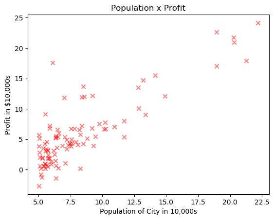

```julia
plotData(X, y);
```

Continue...

## Part 3: Cost and Gradient descent

Add a column of ones to x

```julia
X = [ones(m, 1) data[:,1]];
```

Initialize fitting parameters

```julia
theta = zeros(2, 1);
```

Some gradient descent settings

```julia
iterations = 1500;
alpha = 0.01;
```

Testing the cost function ...

Compute and display initial cost

```julia
include("computeCost.jl");
```

```julia
J = computeCost(X, y, theta);
println("With theta = $(theta)")
println("Cost computed (SQE) = $(J)");
println("Cost computed (RSQE) = $(sqrt(J))");
println("Expected cost value (approx) 32.07");
```

```
With theta = [0.0; 0.0]
Cost computed (SQE) = 32.072733877455676
Cost computed (RSQE) = 5.663279427809975
Expected cost value (approx) 32.07
```

```julia
using Statistics;
```

```julia
mean(y)
```

```
5.839135051546394
```

```julia
quantile(y, [0.0, 0.25, 0.5, 0.75, 1.0])
```

```
5-element Array{Float64,1}:
 -2.6807
  1.9869
  4.5623
  7.0467
 24.147
```

```julia
std(y)
```

```
5.510262255231545
```

Checking the cost with another theta [0; 1]

```julia
computeCost(X, y, [0; 1])
```

```
7.4458555429298965
```

Further testing of the cost function

With theta = [-1 ; 2]

Cost computed

```julia
J = computeCost(X, y, [-1 ; 2])
```

```
54.242455082012384
```

Expected cost value (approx) 54.24

Let's continue...

Running Gradient Descent ...

run gradient descent

```julia
include("gradientDescent.jl");
```

```julia
theta, J_history = gradientDescent(X, y, theta, alpha, iterations);
```

print theta to screen

Theta found by gradient descent:

```julia
theta
```

```
2×1 Array{Float64,2}:
 -3.6302914394043593
  1.166362350335582
```

Expected theta values (approx)

-3.6303

1.1664

```julia
J_history[1:5]
```

```
5-element Array{Float64,1}:
 6.73719046487001
 5.9315935686049555
 5.901154707081388
 5.895228586444222
 5.890094943117332
```

Plot the linear fit

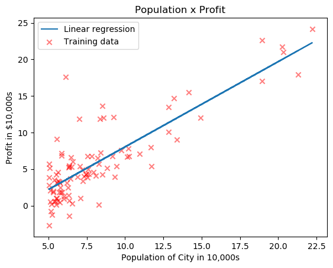

```julia
plotRegression(X, y, theta) = (
    plot(X[:, 2], X * theta, "-");
    plotData(X[:, 2], y);
    legend(["Linear regression", "Training data"]);
)
plotRegression(X, y, theta);
```

Predict values for population sizes of 35,000 and 70,000

```julia
predict1 = [1 3.5] * theta;
```

For population = 35,000, we predict a profit of...

```julia
sum(predict1 * 10000)
```

```
4519.7678677017775
```

```julia
data[6.8 .< data[:X].< 7.01, :]
```

|  | X Float64 | y Float64 |
| --- | --- | --- |
| 1 | 7.0032 | 11.854 |
| 2 | 6.8825 | 3.9115 |

```julia
predict2 = [1 7] * theta;
```

For population = 70,000, we predict a profit of...

```julia
sum(predict2 * 10000)
```

```
45342.45012944714
```

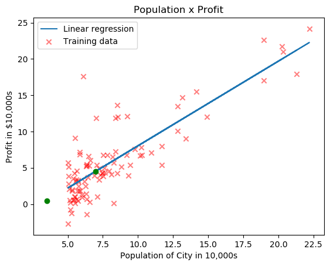

```julia
plotRegression(X, y, theta);
plot([3.5], predict1, color="green", marker="o");
plot([7], predict2, color="green", marker="o");
```

## Part 4: Visualizing J(theta_0, theta_1)

### Visualizing J(theta_0, theta_1)

Grid over which we will calculate J

```julia
theta0_vals = range(-10, stop=10, length=100) |> collect;
theta1_vals = range(-1, stop=4, length=100) |> collect;
```

Initialize J_vals to a matrix of 0's

```julia
J_vals = zeros(length(theta0_vals), length(theta1_vals));
```

Fill out J_vals

```julia
for i = 1:length(theta0_vals)
    for j = 1:length(theta1_vals)
        t = [theta0_vals[i]; theta1_vals[j]];
        J_vals[i, j] = computeCost(X, y, t);
    end
end
```

Because of the way meshgrids work in the surf command, we need to transpose J_vals before calling surf, or else the axes will be flipped

```julia
J_vals = transpose(J_vals);
```

Surface plot

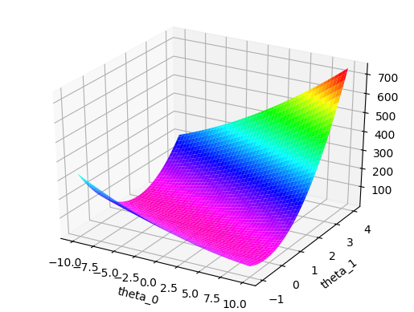

```julia
surf(theta0_vals, theta1_vals, J_vals, cmap="gist_rainbow_r");
xlabel("theta_0");
ylabel("theta_1");
```

### Contour plot

```julia
linspace(start; stop, length) = (exp10.(range(start, stop=stop, length=length)));
```

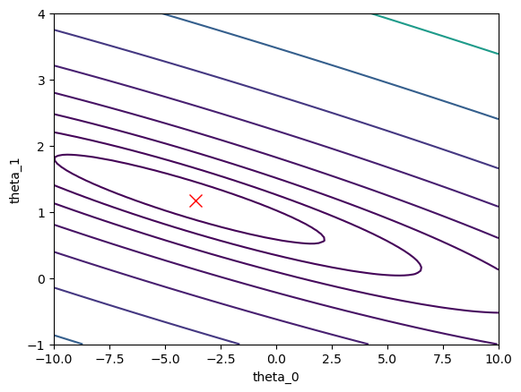

```julia
contour(theta0_vals, theta1_vals, J_vals, linspace(-2, stop=3, length=20));
xlabel("theta_0");
ylabel("theta_1");
plot(theta[1], theta[2], marker="x", markerSize=10, color="red");
```

## Using The GLM Package

The `GLM` package is available for general linear models. We are going to use the `lm` function and compare the results with the previous model

```julia
using GLM; using DataFrames;
```

```
┌ Info: Precompiling GLM [38e38edf-8417-5370-95a0-9cbb8c7f171a]
└ @ Base loading.jl:1186
```

Setting the seed

```julia
using Random; Random.seed!(18735);
```

```julia
modelLM = lm(@formula(y ~ X), data)
```

```
StatsModels.TableRegressionModel{LinearModel{GLM.LmResp{Array{Float64,1}},GLM.DensePredChol{Float64,LinearAlgebra.Cholesky{Float64,Array{Float64,2}}}},Array{Float64,2}}

y ~ 1 + X

Coefficients:
──────────────────────────────────────────────────────────────────────────
             Estimate  Std. Error  t value  Pr(>|t|)  Lower 95%  Upper 95%
──────────────────────────────────────────────────────────────────────────
(Intercept)  -3.89578   0.719483   -5.4147    <1e-6    -5.32413   -2.46743
X             1.19303   0.0797439  14.9608    <1e-25    1.03472    1.35135
──────────────────────────────────────────────────────────────────────────
```

```julia
new_prediction1 = predict(modelLM, DataFrame(X=3.5))
```

```
1-element Array{Union{Missing, Float64},1}:
 0.2798368763516921
```

```julia
new_prediction2 = predict(modelLM, DataFrame(X=7))
```

```
1-element Array{Union{Missing, Float64},1}:
 4.455454631015287
```

The previous predictions are

```julia
predict1
```

```
1×1 Array{Float64,2}:
 0.4519767867701777
```

```julia
predict2
```

```
1×1 Array{Float64,2}:
 4.534245012944714
```

### Root Squared Error

```julia
pred12 = DataFrame(y=[predict1[1], predict2[1]])
```

|  | y Float64 |
| --- | --- |
| 1 | 0.451977 |
| 2 | 4.53425 |

```julia
new_pred12 = DataFrame(y=[new_prediction1[1], new_prediction2[1]])
```

|  | y Float64 |
| --- | --- |
| 1 | 0.279837 |
| 2 | 4.45545 |

```julia
RSQE = round(sqrt(sum(map((x) -> x ^ 2 , (pred12.y - new_pred12.y)))), sigdigits=3)
```

```
0.189
```

which is relatively low

## Plotting Both Results

Using extra points, the plot will show graphically how close the two predictions are.

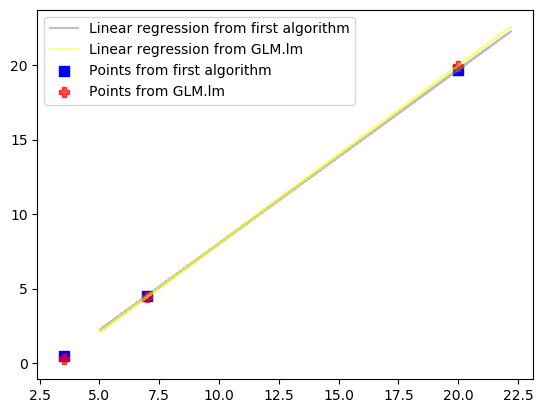

```julia
plot(X[:, 2], X * theta, "-", markerSize=2, color="grey", alpha=0.5);
scatter([3.5, 7], pred12.y, color="blue", marker="s", s=50);
scatter([3.5 7], new_pred12.y, marker="P", alpha=0.7, color="red", s=50);
scatter([20], [1 20] * theta, marker="s", color="blue", s=50);
scatter([20], predict(modelLM, DataFrame(X=20)), marker="P", alpha=0.7, color="red", s=50);
plot(X[:, 2], predict(modelLM, DataFrame(X=X[:, 2])), "-", markerSize=3, color="yellow", alpha=0.5)
legend(["Linear regression from first algorithm",
        "Linear regression from GLM.lm",
        "Points from first algorithm",
        "Points from GLM.lm"]);
```

> *Not bad. Not bad at all :-)*

## GitHub Repository

Code for this exercise can be found on [GitHub](https://github.com/pythongus/machine_learning_with_julia/). Please, let me know if you have any questions. I am Gus Garcia.